# Bidimensional Fuzzy Entropy: FuzzEn2D()

Table of Contents

Syntax: References: About FuzzEn2D(): Note: Example 1: Example 2: Example 3: Example 4:

#### Syntax:

Fuzz2D = FuzzEn2D(Mat, 'm', floor(size(Mat)/10), 'tau', 1, 'Fx', 'default', 'r', [0.2, 2], 'Logx', exp(1), 'Lock', true)

- Mat N x M matrix, where N, M > 10.
- m Embedding dimension, [default: (floor(N/10) floor(M/10))] - an integer > 1 for square submatrix embedding, or a two-element vector of integers > 1 representing the height and width of the template submatrix.
- tau Time delay, a positive integer.
- Fx Type of fuzzy function for distance transformation, one of the following strings: 'default' / 'sigmoid' / 'modsampen' / 'gudermannian' / 'linear'. See the EntropyHub Guide (.pdf) for more info.
- r Parameters of the fuzzy function specified by Fx, a 1 element scalar or a 2 element tuple of positive values depending on the fuzzy function as shown above. Default: Two element vector / Sigmoid/ModSampEn: Two element vector / Gudermannian: A scalar value / Linear: 0 or 1
- Logx Logarithm base in Shannon's entropy formula, a positive scalar.
- Lock See note on matrix size locking true Matrix height (N) and width (M)
- Fuzz2D Bidimensional fuzzy entropy estimate.

#### References:

1. Luiz Fernando Segato Dos Santos, et al., Multidimensional and fuzzy sample entropy (SampEnMF) for quantifying H & E histological images of colorectal cancer, Computers in biology and medicine 103 (2018): 148-160.
2. Mirvana Hilal and Anne Humeau-Heurtier, Bidimensional fuzzy entropy: Principle analysis and biomedical applications, 41st Annual International Conference of the IEEE (EMBC) Society 2019.

#### About FuzzEn2D():

FuzzEn2D has an important keyword argument: Lock. Bidimensional entropy functions are "locked" by default (Lock == true) to only permit matrices with a maximum size of 128 x 128. The reason for this is because there are hundreds of millions of pairwise calculations performed in the estimation of bidimensional entropy, so memory errors often occur when storing data on RAM. e.g. For a matrix of size [200 x 200], an embedding dimension (m) = 3, and a time delay (tau) = 1, there are 753,049,836 pairwise matrix comparisons (6,777,448,524 elemental subtractions). To pass matrices with sizes greater than [128 x 128], set 'Lock' to false.

*** WARNING: unlocking the permitted matrix size may cause MatLab to crash.***

#### Note:

In the following examples, sample matrices are imported into MatLab using the ExampleData function from EntropyHub.

To use this function as outlined in the examples below, an internet connection is required.

ExampleData accepts any of the following strings:

- 'uniform_Mat' uniformly distributed random numbers in range [0 1]
- 'gaussian_Mat' normally distributed random numbers with mean = 0, and standard deviation = 1
- 'randintegers_Mat' uniformly distributed pseudorandom integers in range [1 8]
- 'mandelbrot_Mat' image of fractal generated from the mandelbrot set
- 'entropyhub_Mat' image of the entropyhub logo

#### Example 1:

Import a matrix of uniformly distributed random numbers in the range [0, 1].

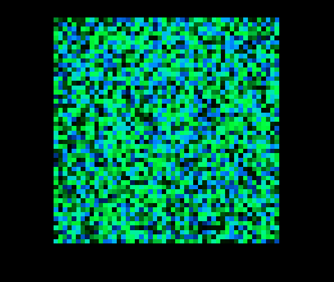

```matlab
X = ExampleData('uniform_Mat');

figure('Color','k'),
imshow(X,'InitialMagnification',750),
cmap = colormap('turbo'); cmap(:,1) = 0;
colormap(cmap)
```

```matlab
FE2D = FuzzEn2D(X)
```

FE2D = 1.3475

Change the size of the template matrix to [6 x 6].

```matlab
FE2D = FuzzEn2D(X, 'm', 6)
```

FE2D = 1.1034

Change the scaling parameters (r) of the 'default' fuzzy function:

```matlab
FE2D = FuzzEn2D(X, 'm', 6, 'r', [3, 1.5])
```

FE2D = 0.0106

#### Example 2:

Import a matrix of uniformly distributed pseudorandom integers in the range [1, 8] and calculate the bidimensional fuzzy entropy with a template matrix of size [3 x 2] and a time delay (tau) of 4 using the gudermannian fuzzy function:

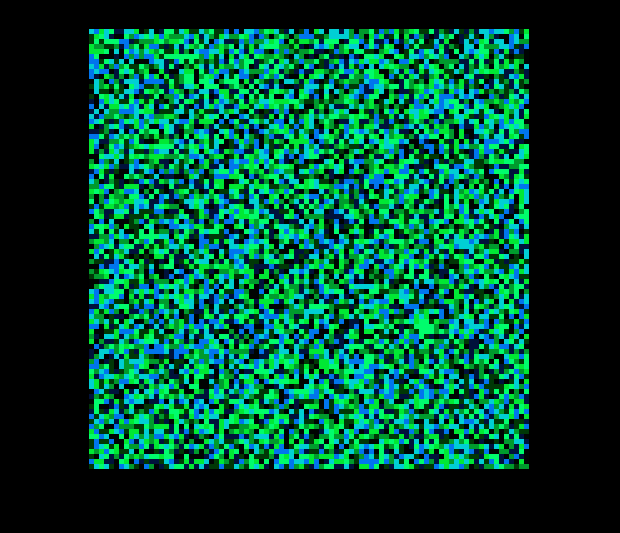

```matlab
X = ExampleData('randintegers_Mat');

figure('Color','k'),
imshow(X,[],'InitialMagnification',500),
cmap = colormap('turbo'); cmap(:,1) = 0;
colormap(cmap)
```

```matlab
FE2D = FuzzEn2D(X, 'm', [3 2], 'tau', 4, 'Fx', 'gudermannian', 'r', 2.5)
```

FE2D = 0.0518

#### Example 3:

Import an image of a Mandelbrot fractal as a matrix.

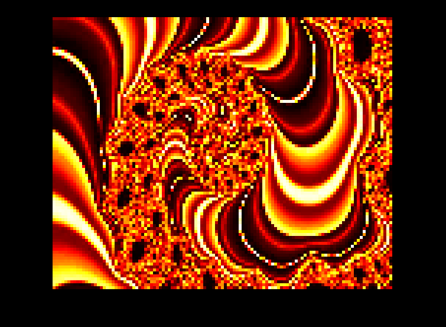

```matlab
X = ExampleData('mandelbrot_Mat');

figure('Color','k'),
imshow(X,[],'InitialMagnification',500),
colormap('hot')
```

Calculate the bidimensional fuzzy entropy in trits (logarithm base 3) with a template matrix of size [8 x 5], and a time delay (tau) of 2 using a 'linear' fuzzy function with distances linearly normalised to the range [0, 1]

```matlab
FE2D = FuzzEn2D(X, 'm', [8 5], 'tau', 2, 'Fx', 'linear', 'r', 0, 'Logx', 3)
```

FE2D = 0.0016

#### Example 4:

Import an image of the EntropyHub logo as a matrix and calculate the bidimensional fuzzy entropy in bits (logarithm base 2) using the 'modsampen' (sigmoid) fuzzy function with fuzzy function parameters (r) = (1.25, .75) and all other default parameters :

[figure not shown]

```matlab
X = ExampleData('entropyhub_Mat');

figure('Color','k'),
imshow(X,[],'InitialMagnification',500),
colormap('cool')
```

```matlab
FE2D = FuzzEn2D(X, 'Fx', 'modsampen', 'r', [1.25 0.75], 'Logx', 2)
```

FE2D = 0.2588